# Marketing Analytics

## Two ways to randomize

**Between-subjects**

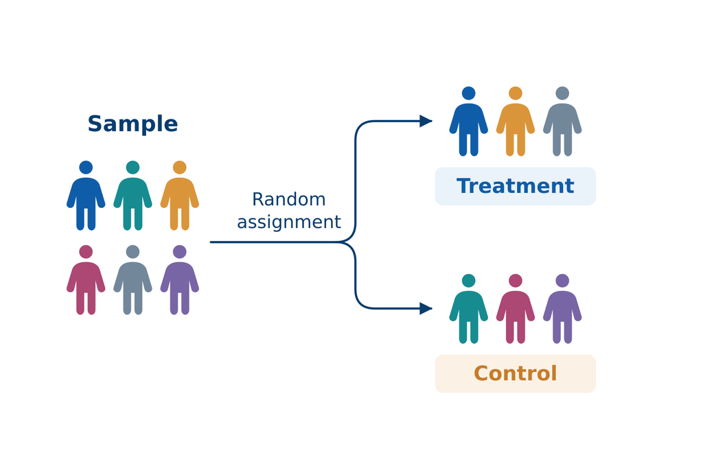

Each person is randomly assigned to **one** condition — we compare **different people**.

**Within-subjects**

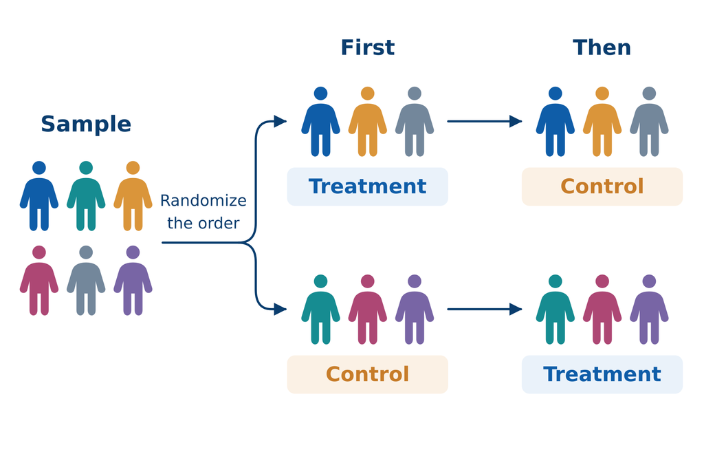

Each person experiences **all** conditions, in random order — we compare **the same people**.

## Between vs. within subjects: pros and cons

|  | **Between-subjects** | **Within-subjects** |
| --- | --- | --- |
| Design | Each person sees **one** condition | Each person sees **all** conditions (repeated measures) |
| Example | Group A: targeted ad · Group B: generic ad | Everyone rates ad no. 1, then ad no. 2 |
| Comparison | **Across people:** mean(A) vs. mean(B) | **Within person:** condition 1 vs. condition 2 |
| Pros | No order or carryover effects · **realistic:** customers usually see only one version | Each person is their **own control** → can require **fewer participants**, *if* responses are correlated and carryover is limited |
| Cons | **More participants** needed · groups differ by chance → more noise | **Carryover:** the first condition can change the response to the second (learning, anchoring, a purchase already made) — counterbalancing helps, but cannot undo it |

**Rule of thumb:** within-subjects for **judgments** that do not change the person (rating ads, tasting products). Between-subjects for **behavior** (purchases, clicks) — or whenever the first exposure could change the response to the second. Online A/B tests keep each user in **one** condition.

## Why the industry runs on experiments

> *“Our success at Amazon is a function of how many experiments we do per year, per month, per week, per day.”*

> — Jeff Bezos

> *“At any given point in time, there isn’t just one version of Facebook running, there are probably 10,000.”*

> — Mark Zuckerberg

**A/B test** = industry name for a between-subjects randomized experiment, run continuously and at scale.

## Guidelines for field experiments

1. **Choose the unit of randomization.** Finer units (users rather than regions) → more statistical power — but weigh against logistics and spillovers. In digital environments, user-level A/B tests make fine granularity cheap
2. **Watch for spillovers & crossover.** *Spillover*: Treated units can affect untreated ones (product adoption spreads to friends; a tipping prompt changes driver behavior for *all* riders — Uber, Chandar et al. 2019). If spillovers loom, randomize at a **higher level** (households, cities). *Crossover*: a unit meant for control gets treated anyway (multiple devices, shared accounts)
3. **Complete vs. stratified randomization.** Pure coin flips can leave small samples imbalanced by chance. **Stratify**: split units into homogeneous subgroups first, randomize within each — worth it when a covariate strongly predicts the outcome

Lambrecht & Tucker (2016); Chandar, Gneezy, List & Muir (2019).

## The price of observational data

**Experimental research**

> *“To find out what happens when you change something, it is necessary to change it.”*

> — Box, Hunter & Hunter (1978)

**Observational research**

> *“Behind any causal conclusion there must be some causal assumption, untested in observational studies.”*

> — Pearl (2009)

That untested assumption has a name: **no unobserved confounders** — every variable driving both treatment and outcome has been measured and correctly adjusted for.

- **Untestable in principle**: you cannot check balance on variables you did not observe
- Experiments **buy** the assumption *by design*; observational studies must **argue** for it — with domain knowledge, not statistics

## In-class reading: does personalization pay?

Harvard Business Review · December 2021

**Does Personalized Advertising Work as Well as Tech Companies Claim?**

*Bart de Langhe & Stefano Puntoni*

[→ https://hbr.org/2021/12/does-personalized-advertising-work-as-well-as-tech-companies-claim](https://hbr.org/2021/12/does-personalized-advertising-work-as-well-as-tech-companies-claim)

[figure not shown]

**Take ~10 minutes** to read the article.

**Then discuss:**

1. According to its **objective**, what type of research question is being asked here — descriptive, predictive, causal, or prescriptive?
2. What exactly makes it **difficult to measure** the effect of personalized ads on sales?

de Langhe & Puntoni (2021), “Does Personalized Advertising Work as Well as Tech Companies Claim?”, *Harvard Business Review*, December 16.

## Threats to causal inference: who sees a personalized ad?

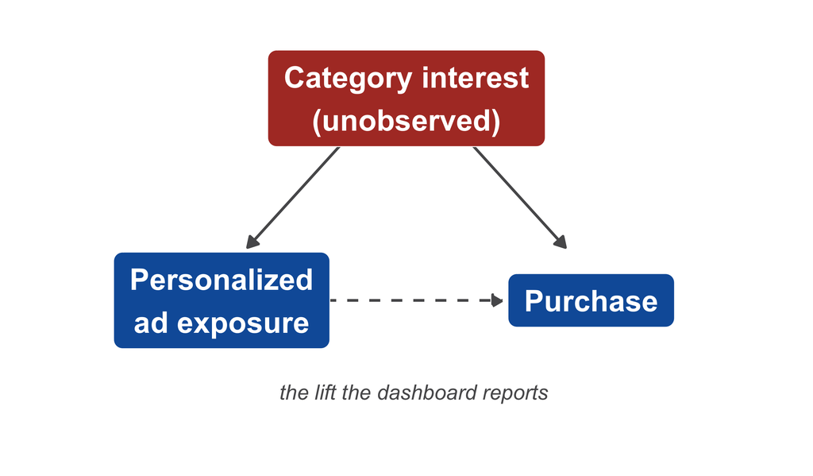

**Selection bias, machine-made:** the targeting algorithm shows the ad *to people already interested in the category* — the platform **optimizes** for finding exactly the users who would buy anyway. Nobody chose anything; the selection happened inside the algorithm.

## Even A/B tests can break: divergent delivery

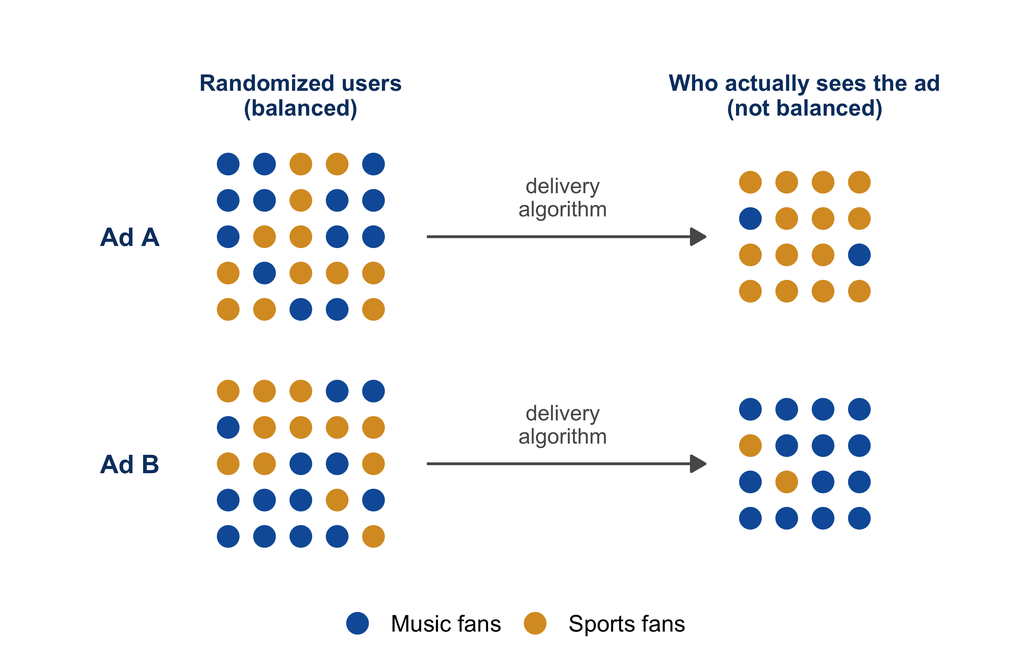

- **Divergent delivery:** ad platforms’ algorithms deliver different ads to **systematically different mixes of users — even during A/B tests**, confounding the effect of ad *content* with *targeting* effects
- **Consequence for inference:** the lack of balance can distort both the **magnitude and the sign** of estimated ad differences
- **Managerial implication:** platform A/B tools are useful for picking the better-performing ad **within the same platform** — they cannot reveal the true causal effect of ad content **across contexts, platforms, or audiences**

Braun & Schwartz (2025), “Where A/B Testing Goes Wrong: How Divergent Delivery Affects What Online Experiments Cannot (and Can) Tell You About How Customers Respond to Advertising”, *Journal of Marketing*, 89(2), doi:10.1177/00222429241275886. Illustration: own, stylized.

# 1.7 Quasi-experiments

## Between the poles: quasi-experiments

> *“Quasi-experimental tools mimic the random assignment that is inherent in lab experiments and that is often referred to as the ‘gold standard’ for identifying causal relationships.”*

> — Goldfarb & Tucker (2014)
- The “randomization” comes from an **exogenous shock** — a market entry, a policy change, a staggered rollout — **not controlled by the researcher**
- Units still **self-select** into treatment and control → the challenge is to argue that the shock **credibly proxies for random assignment**
- Often **fewer external-validity concerns** than lab experiments: real people, real markets, real money
- Workhorse estimator: **difference-in-differences (DiD)**

## A spectrum of designs

|  | Experiment | Quasi-experiment | Observational |
| --- | --- | --- | --- |
| Who assigns treatment? | The researcher (coin flip) | External event / rule | The units themselves |
| Example | A/B test of a discount | Platform launches in some countries first | Newsletter readers vs. non-readers |
| Key requirement | Correct execution | “As-good-as-random” timing/rule | **No unobserved confounders** |

## Example: does streaming cannibalize music sales?

- **Wlömert & Papies (2016):** effect of music streaming on (1) demand in **other channels** (downloads, CDs) and (2) **total** music industry revenues
- A typical **multi-channel distribution** problem in marketing
- **Spotify’s market entry** = quasi-experiment
- Observation: Spotify users spend **more** on music in other channels than non-users

**What the press concluded:**

*“Netflix Isn’t Killing Movie Theaters, Study Shows”*  
[— Variety, 2018](https://variety.com/2018/film/news/streaming-netflix-movie-theaters-1203090899/)

*“Spotify Users Are Twice as Likely to Purchase a Download…”*  
— Digital Music News, 2012

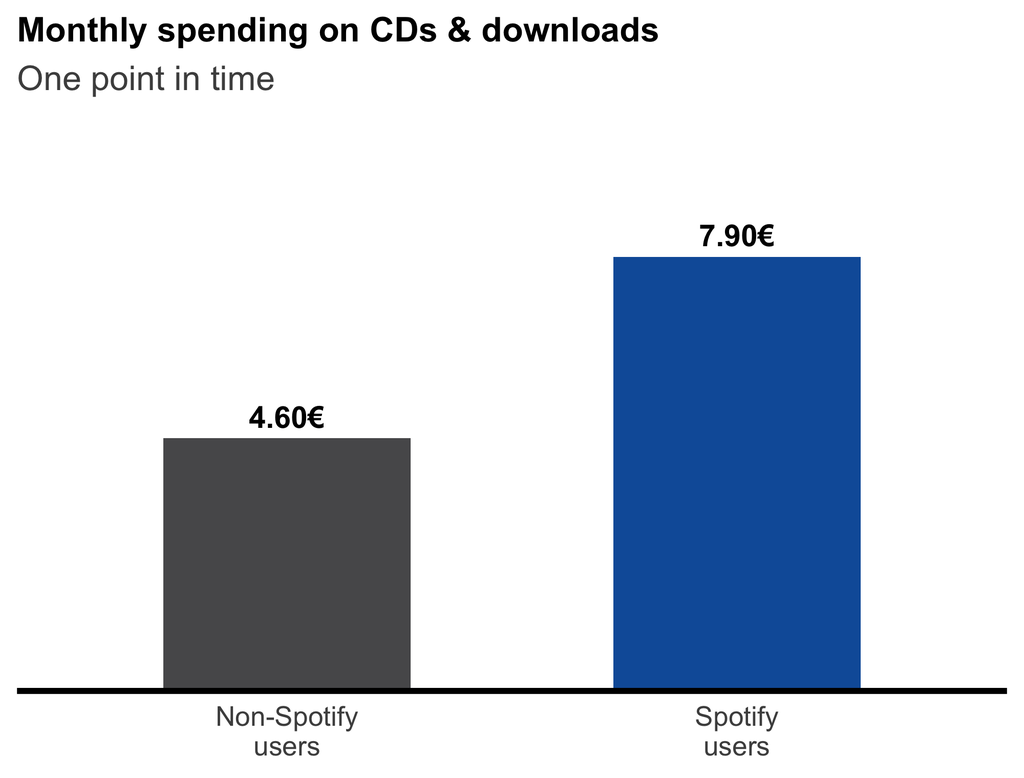

**Is this evidence of a causal effect?** Would you conclude that streaming *boosts* CD and download sales?

Wlömert & Papies (2016), *International Journal of Research in Marketing*, 33(2), 314–327. Press headlines: Variety (2018); Digital Music News (2012).

## Snapshots vs. following people over time

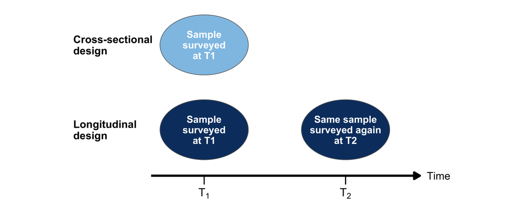

A **longitudinal (panel) design** observes the **same units** repeatedly — so we can see how each group **changes** over time, not just where it stands.

## Difference-in-differences: the logic

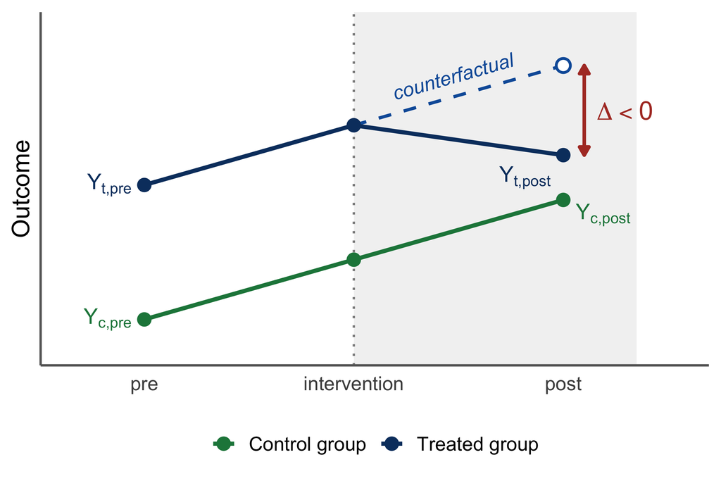

| Period | Treated | Control | Counterfactual |
| --- | --- | --- | --- |
| Before | $Y_{t,\text{pre}}$ | $Y_{c,\text{pre}}$ | $Y_{t,\text{pre}}$ |
| After | $Y_{t,\text{post}}$ | $Y_{c,\text{post}}$ | $Y_{t,\text{pre}} + (Y_{c,\text{post}} - Y_{c,\text{pre}})$ |

**Effect of the treatment on the treated (Δ):**

$$\Delta = (Y_{t,\text{post}} - Y_{t,\text{pre}}) - (Y_{c,\text{post}} - Y_{c,\text{pre}})$$

**Key assumption — parallel trends:** without the treatment, the treated group would have changed **by the same amount** as the control group.

Adapted from Varian (2016), “Causal inference in economics and marketing”, *PNAS*, 113(27), 7310–7315.

## DiD in action: the Spotify example

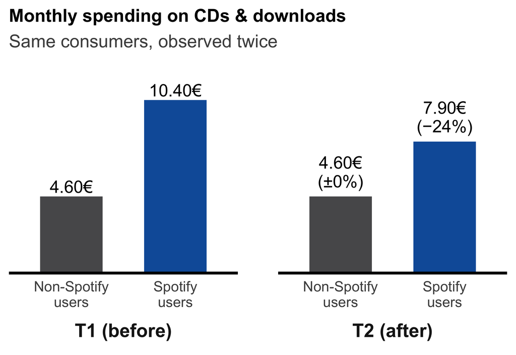

| Period | Treated | Control | Counterfactual |
| --- | --- | --- | --- |
| Before | 10.40€ | 4.60€ | 10.40€ |
| After | 7.90€ | 4.60€ | 10.40€ + (4.60€ − 4.60€) |

**Effect of the treatment on the treated (Δ):**

(7.90€ − 10.40€) − (4.60€ − 4.60€) = **−2.50€**

**Same data, opposite conclusion:** the snapshot says Spotify users spend **+3.30€ more**; following the same people over time says Spotify **reduces** their spending by **2.50€** per month. The snapshot measured *who adopts*, not *what adoption does*.

Wlömert & Papies (2016), *International Journal of Research in Marketing*, 33(2), 314–327. Stylized figures.

# 1.8 From business problem to research design

## The translation template

**Manager:** *“I want to know whether our loyalty program is worth the money.”*

| Design element | Your translation |
| --- | --- |
| **Outcome (DV)** | Customer contribution margin, 12 months |
| **Treatment (IV)** | Loyalty program membership |
| **Unit of analysis** | Customer |
| **Question type** | Causal (→ prescriptive decision) |
| **Likely confounders** | Purchase frequency & engagement *before* joining |
| **Feasible design?** | Randomize invitations? Staggered regional rollout? Observational + adjustment? |

A precise, falsifiable formulation (“membership increases 12-month margin”) beats a vague aspiration (“the program creates value”) — it dictates data, design, and analysis.

## Your turn (pairs, 10 min)

**Translate one of these into the template:**

1. “Should we invest more in influencer marketing?”
2. “Is our app driving retention, or do loyal customers just download the app?”
3. “Did last spring’s rebranding damage sales in Germany?”

For each: DV, IV, unit, question type, two plausible confounders, and the **best feasible design** (experiment / quasi-experiment / observational).

# 1.9 The analytics workflow

## Where AI helps — and where it cannot replace you

| Workflow step | Nature of the work | AI assistant… |
| --- | --- | --- |
| Formulate the question | **Judgment** | can challenge you — cannot know your business |
| Choose design & method | **Judgment** | suggests options — *you* own the assumptions |
| Write & debug R code | Mechanical | **excellent** — use it freely, including in this course |
| Interpret results | **Judgment** | drafts text — but cannot verify the causal claim |
| Communicate to stakeholders | Mixed | strong support, needs your framing |

**Course policy in one line:** use AI to *accelerate* your learning of the judgment steps, not to *skip* them. Assessments in this course are designed so that the judgment steps are what earns the points.

## One map for the whole course

| Module | Sessions | Driving question |
| --- | --- | --- |
| 1 · Questions, decisions & data | 1 *(today)* | Which question am I really asking? |
| 2 · Describing data | 2 | What is going on? |
| 3 · Uncertainty | 3 | How sure can I be? |
| 4 · Learning from experiments | 3 / 4 | Did it work? |
| 5 · Learning from observational data | 5 / 6 | What if we cannot randomize? |
| 6 · Mechanisms & heterogeneity | 7 | Why — and for whom — does it work? |
| Survey design | 8 | How do I build a study that can answer my question? |
| Group project coaching | 2 online sessions | Your own experiment, end to end |
| Final exam (in person) | Tue, Dec 15 | — |

## Learning check — can you spot the reasoning?

1. An analyst reports: *“App users have 2× the lifetime value of non-users — the app clearly pays off.”* Which question type is being **answered**, which is being **claimed**? Name the most plausible confounder.
2. A platform’s advertising dashboard compares purchases of users who clicked an ad vs. users who saw it and didn’t click. Is this an experiment? What role does “interest in the product” play?
3. Your CMO ran a 4-week price promotion **in Vienna only**. Weekly sales in Vienna rose from **200k€ to 230k€**; in Graz (no promotion) from **150k€ to 160k€** over the same weeks. What is the **difference-in-differences** estimate? What must you **assume** for it to be causal?
4. Confounder, mediator, or moderator? (a) The newsletter increases purchases *because it increases site visits*. (b) The discount works much better *for students*. (c) Customers who buy our cereal also buy more of our toys — *households with more children* buy more of both.

## Learning check — true or false?

1. A sufficiently large dataset removes the need for the no-unobserved-confounders assumption.
2. Randomization balances treatment groups even on characteristics that were never measured.
3. A variable can be an excellent predictor of an outcome without having any causal effect on it.
4. Two time series that both trend upward will be correlated — even if they are completely unrelated.
5. If Spotify users spent more on music than non-users *before* adopting Spotify, difference-in-differences cannot be used.
6. In a platform A/B test, randomizing users into ad A vs. ad B guarantees that both ads reach comparable audiences.

**Preview:** the paper quiz at the start of each session looks like this — short, conceptual, no R.

## Next session

**Module 2 · Describing data** — *What is going on?*

- Getting data into R, cleaning it, and not trusting it too early
- Summary statistics and the visualizations that earn their place
- **Before the session:** complete the R onboarding module — link on the course site.

Course book chapter 1 (consolidation reading for today) is online — including all simulated examples from these slides, with their code.